# IAG Lasso Regression

Andrea De Stefano

2023-02-14

## LASSO Regression

LASSO (Least Absolute Shrinkage and Selection Operator) is a regularization technique that shrink data values towards a central point as the mean. The lasso procedure is well-suited for models showing high levels of multicollinearity or for variable selection/parameter elimination.

LASSO is usually considered a better alternative than stepwise regression. Harrell in “Regression Modeling Strategies” (2001), listed the following problems with stepwise regression:

1. R^2 values are biased high.
2. The F statistics do not have the claimed distribution.
3. The standard errors of the parameter estimates are too small.
4. The confidence intervals around the parameter estimates are too narrow.
5. p-values are too small because to multiple comparisons, and are difficult to correct.
6. Parameter estimates are biased away from 0.
7. Collinearity problems are exacerbated.

Which means:

1. Parameter estimates are likely to be too far away from zero.
2. The variance estimates for those parameter estimates are not correct either
3. Confidence intervals and hypothesis tests will be wrong
4. Very hard, if not impossible, correcting these problems.

In LASSO, regularization is implemented by adding a “penalty” term to the best fit derived from the trained data, to achieve a lesser variance with the tested data and also restricts the influence of predictor variables over the output variable by compressing their coefficients.

L1 (LASSO) regularization adds a penalty that is equal to the absolute value of the magnitude of the coefficient. This regularization type can result in sparse models with few coefficients. Some coefficients might become zero and get eliminated from the model. Larger penalties result in coefficient values that are closer to zero (ideal for producing simpler models).

This Document has 2 parts:

1. Data manipulation, assumption checking, outliers and influential observations treatment.
2. Implementation of LASSO regression with Tidymodels.

The dataset used is from my postdoc project, related to invasive annual grasses.

More info on LASSO can be found on:

https://towardsdatascience.com/stopping-stepwise-why-stepwise-selection-is-bad-and-what-you-should-use-instead-90818b3f52df

https://juliasilge.com/blog/lasso-the-office/

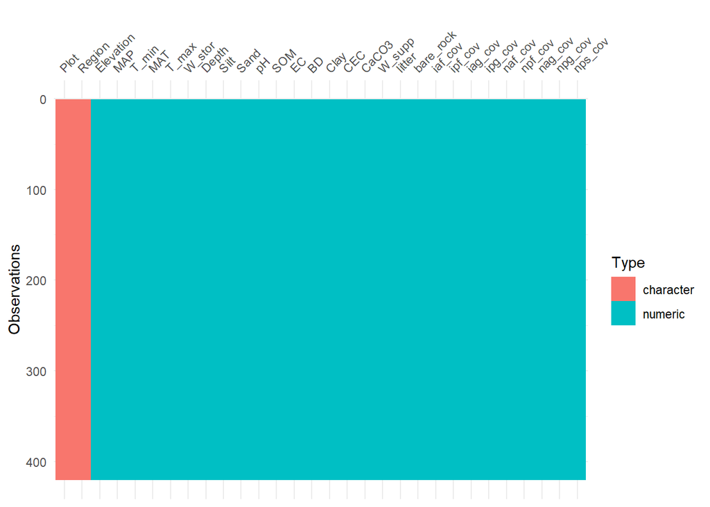

```r
library(tidyverse)
library(tidymodels)
library(MASS)
library(car)
library(doParallel)
library(vip)
library(visdat)
library(glmnet)
library(ggpubr)
library(knitr)

# Import data

trial2 <- read.csv("https://raw.githubusercontent.com/azd169/postdoc/main/trial2.csv?",
                 header = T)

# Removing some unnecessary variables

trial2_clean1 <- trial2 %>%
  dplyr::select(
    -c(Plt, Site, Lat, Lon, State,
       Aspect, Northerness, Easterness, Slope, Texture,
#       Silt, Sand, Clay,
#       pH, SOM, EC, BD, Depth, CEC, CaCO3,
       treatment, trt1, trt2, trt1rate, trt2rate,
       collection_date, target,
       pielou, effective, Inv_Simp, Simpson, rich,  Shannon,  Shannon_nat,
       intr_cov, nat_cov, gen_cov,
       ips_cov,
       59:99)
  )

# Visualize variables by type

vis_dat(trial2_clean1)
```

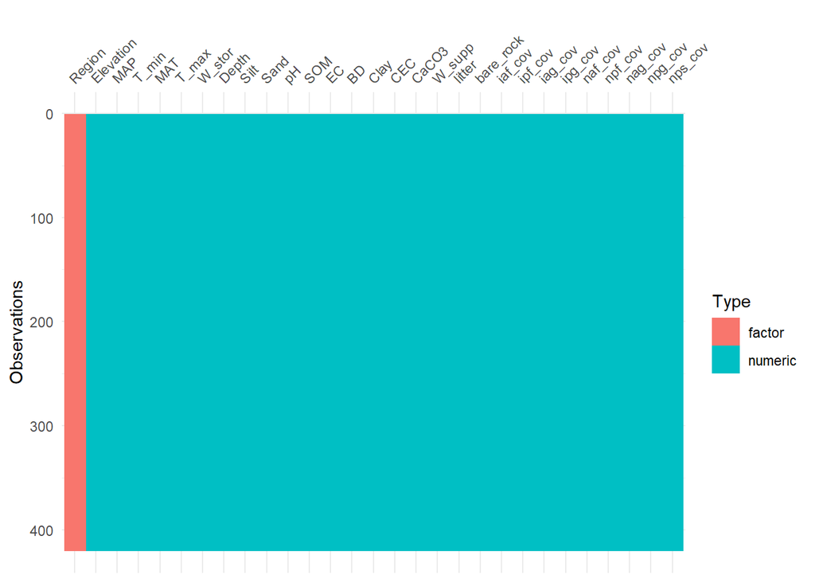

```r
# Change some var type

trial2_clean2 <-
  trial2_clean1 %>%
  dplyr::mutate_if(is.integer, as.numeric) %>%
  mutate(Region = as.factor(Region)) %>% # Level 2 Ecoregion is a factor with 3 levels
  dplyr::select(-c(Plot))

vis_dat(trial2_clean2)
```

```r
# Assumptions

par(mfrow = c(2, 2))

mod_iag <- lm(iag_cov ~., trial2_clean2) # Linear regression model IAG

summary(mod_iag)
```

```
##
## Call:
## lm(formula = iag_cov ~ ., data = trial2_clean2)
##
## Residuals:
##     Min      1Q  Median      3Q     Max
## -38.318 -10.840  -2.546   7.709  69.605
##
## Coefficients:
##                                                  Estimate Std. Error t value
## (Intercept)                                    -8.174e+02  3.294e+02  -2.481
## RegionWest and South Central Semiarid Prairies -1.488e+00  4.256e+00  -0.350
## RegionWestern Cordillera                        3.303e+00  2.277e+00   1.451
## Elevation                                       1.037e-03  5.214e-03   0.199
## MAP                                            -3.398e-03  1.325e-02  -0.257
## T_min                                          -1.424e+00  7.382e-01  -1.928
## MAT                                             4.521e-01  7.321e-01   0.618
## T_max                                           2.021e+00  1.738e+00   1.163
## W_stor                                          3.893e-01  3.642e-01   1.069
## Depth                                           9.755e-03  7.643e-02   0.128
## Silt                                            7.867e+00  3.202e+00   2.457
## Sand                                            7.627e+00  3.150e+00   2.422
## pH                                              1.005e+01  5.843e+00   1.719
## SOM                                             9.873e+00  1.357e+01   0.728
## EC                                             -3.462e+00  1.429e+00  -2.422
## BD                                             -9.742e+00  2.110e+01  -0.462
## Clay                                            7.767e+00  3.257e+00   2.385
## CEC                                            -8.074e-03  5.308e-01  -0.015
## CaCO3                                          -6.791e-02  3.138e-02  -2.164
## W_supp                                         -2.093e-02  2.006e-02  -1.044
## litter                                         -1.482e-01  4.600e-02  -3.221
## bare_rock                                      -3.973e-01  6.261e-02  -6.346
## iaf_cov                                         5.040e-03  1.446e-01   0.035
## ipf_cov                                        -7.617e-01  2.061e-01  -3.696
## ipg_cov                                        -4.454e-01  1.125e-01  -3.958
## naf_cov                                        -2.099e-01  1.283e-01  -1.636
## npf_cov                                        -1.777e-01  7.197e-02  -2.469
## nag_cov                                        -4.456e-01  5.070e-01  -0.879
## npg_cov                                        -4.608e-01  7.204e-02  -6.397
## nps_cov                                        -2.293e-01  6.565e-02  -3.493
```

[output cut: 22 more lines]

```
## bare_rock                                      6.15e-10 ***
## iaf_cov                                        0.972213
## ipf_cov                                        0.000250 ***
## ipg_cov                                        8.99e-05 ***
## naf_cov                                        0.102628
## npf_cov                                        0.013995 *
## nag_cov                                        0.379940
## npg_cov                                        4.54e-10 ***
## nps_cov                                        0.000533 ***
## ---
## Signif. codes:  0 '***' 0.001 '**' 0.01 '*' 0.05 '.' 0.1 ' ' 1
##
## Residual standard error: 16.1 on 390 degrees of freedom
## Multiple R-squared:  0.3579, Adjusted R-squared:  0.3101
## F-statistic: 7.495 on 29 and 390 DF,  p-value: < 2.2e-16
```

```r
anova(mod_iag) # R coding for dummy variable (Region)
```

```
## Analysis of Variance Table
##
## Response: iag_cov
##            Df Sum Sq Mean Sq F value    Pr(>F)
## Region      2   1430   715.0  2.7576 0.0646783 .
## Elevation   1   5363  5363.5 20.6849 7.238e-06 ***
## MAP         1   1902  1901.6  7.3337 0.0070653 **
## T_min       1   5679  5679.0 21.9017 3.965e-06 ***
## MAT         1   2081  2080.7  8.0246 0.0048540 **
## T_max       1   1755  1754.8  6.7678 0.0096351 **
## W_stor      1     25    24.6  0.0951 0.7580041
## Depth       1     66    65.7  0.2534 0.6150083
## Silt        1    266   265.9  1.0256 0.3118152
## Sand        1   2737  2736.5 10.5537 0.0012600 **
## pH          1   1131  1130.8  4.3609 0.0374207 *
## SOM         1    392   391.6  1.5104 0.2198152
## EC          1   1572  1572.2  6.0634 0.0142324 *
## BD          1    715   714.5  2.7556 0.0977182 .
## Clay        1    383   382.8  1.4765 0.2250597
## CEC         1    937   936.7  3.6124 0.0580857 .
## CaCO3       1   1149  1149.0  4.4311 0.0359291 *
## W_supp      1     40    39.9  0.1539 0.6950324
## litter      1     81    81.2  0.3133 0.5759836
## bare_rock   1   7423  7423.3 28.6289 1.498e-07 ***
## iaf_cov     1     16    15.7  0.0607 0.8055287
## ipf_cov     1   4168  4168.0 16.0742 7.299e-05 ***
## ipg_cov     1   2263  2262.8  8.7267 0.0033258 **
## naf_cov     1      3     2.9  0.0112 0.9158725
## npf_cov     1   1589  1589.3  6.1293 0.0137201 *
## nag_cov     1    409   409.4  1.5787 0.2096986
## npg_cov     1   9624  9624.1 37.1166 2.671e-09 ***
## nps_cov     1   3163  3163.4 12.2001 0.0005326 ***
## Residuals 390 101125   259.3
## ---
## Signif. codes:  0 '***' 0.001 '**' 0.01 '*' 0.05 '.' 0.1 ' ' 1
```

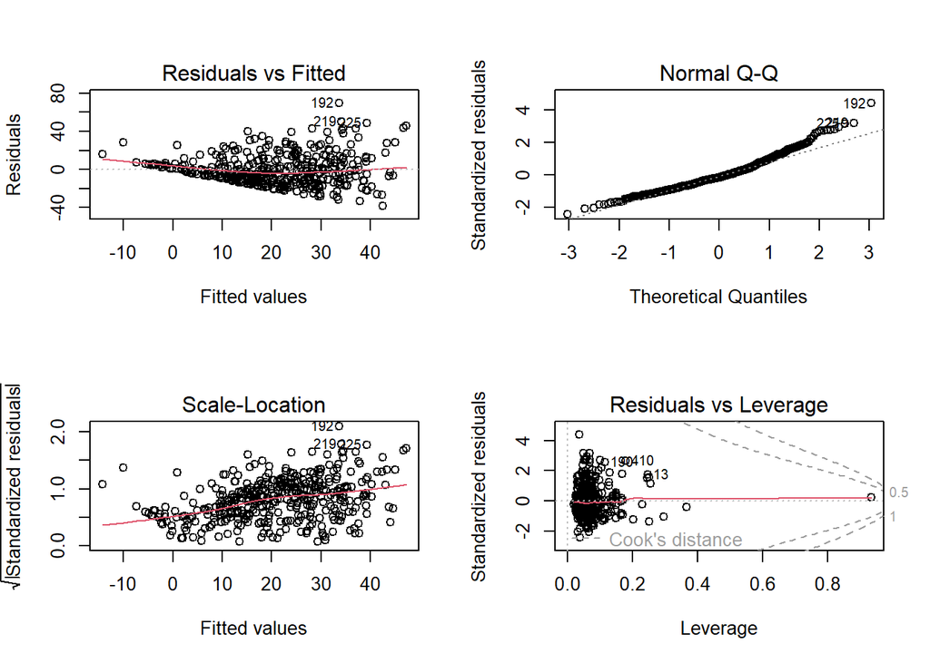

```r
plot(mod_iag) # iag_cov is non linear and heteroscedastic. Transform
```

```r
mod_iag_sqrt <- lm(sqrt(iag_cov) ~.,
                 data = trial2_clean2) # Square root transformation

summary(mod_iag_sqrt)
```

```
##
## Call:
## lm(formula = sqrt(iag_cov) ~ ., data = trial2_clean2)
##
## Residuals:
##     Min      1Q  Median      3Q     Max
## -4.6865 -1.1988 -0.0709  1.1235  4.7195
##
## Coefficients:
##                                                  Estimate Std. Error t value
## (Intercept)                                    -1.215e+02  3.648e+01  -3.331
## RegionWest and South Central Semiarid Prairies  6.517e-02  4.712e-01   0.138
## RegionWestern Cordillera                        5.444e-01  2.521e-01   2.160
## Elevation                                      -4.056e-04  5.773e-04  -0.703
## MAP                                            -9.202e-04  1.466e-03  -0.627
## T_min                                          -2.382e-01  8.173e-02  -2.914
## MAT                                             4.204e-02  8.105e-02   0.519
## T_max                                           2.464e-01  1.924e-01   1.281
## W_stor                                          4.132e-02  4.032e-02   1.025
## Depth                                           3.844e-03  8.462e-03   0.454
## Silt                                            1.202e+00  3.546e-01   3.391
## Sand                                            1.169e+00  3.487e-01   3.351
## pH                                              1.146e+00  6.469e-01   1.771
## SOM                                             7.284e-02  1.502e+00   0.048
## EC                                             -3.458e-01  1.583e-01  -2.185
## BD                                             -1.723e-01  2.336e+00  -0.074
## Clay                                            1.202e+00  3.606e-01   3.334
## CEC                                            -4.013e-02  5.877e-02  -0.683
## CaCO3                                          -1.076e-02  3.474e-03  -3.098
## W_supp                                         -4.700e-03  2.221e-03  -2.116
## litter                                         -2.435e-02  5.093e-03  -4.782
## bare_rock                                      -4.661e-02  6.933e-03  -6.723
## iaf_cov                                         4.068e-03  1.601e-02   0.254
## ipf_cov                                        -8.963e-02  2.282e-02  -3.929
## ipg_cov                                        -5.480e-02  1.246e-02  -4.398
## naf_cov                                        -2.021e-02  1.420e-02  -1.423
## npf_cov                                        -2.164e-02  7.968e-03  -2.716
## nag_cov                                        -6.624e-02  5.613e-02  -1.180
## npg_cov                                        -5.758e-02  7.976e-03  -7.219
## nps_cov                                        -2.710e-02  7.269e-03  -3.728
```

[output cut: 22 more lines]

```
## bare_rock                                      6.34e-11 ***
## iaf_cov                                        0.799543
## ipf_cov                                        0.000101 ***
## ipg_cov                                        1.41e-05 ***
## naf_cov                                        0.155619
## npf_cov                                        0.006907 **
## nag_cov                                        0.238722
## npg_cov                                        2.75e-12 ***
## nps_cov                                        0.000221 ***
## ---
## Signif. codes:  0 '***' 0.001 '**' 0.01 '*' 0.05 '.' 0.1 ' ' 1
##
## Residual standard error: 1.783 on 390 degrees of freedom
## Multiple R-squared:  0.4153, Adjusted R-squared:  0.3718
## F-statistic: 9.552 on 29 and 390 DF,  p-value: < 2.2e-16
```

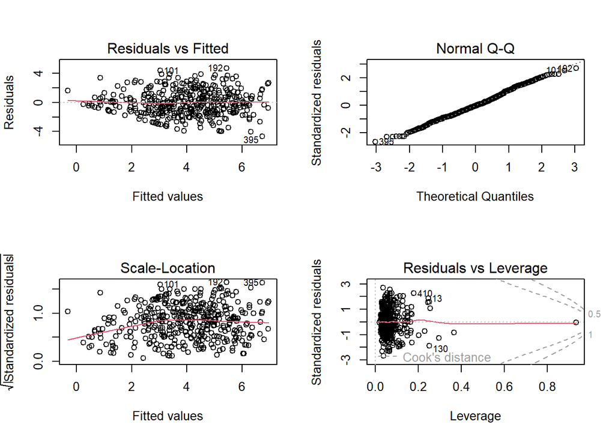

```r
plot(mod_iag_sqrt) # sqrt(iag_cov) looks good now
```

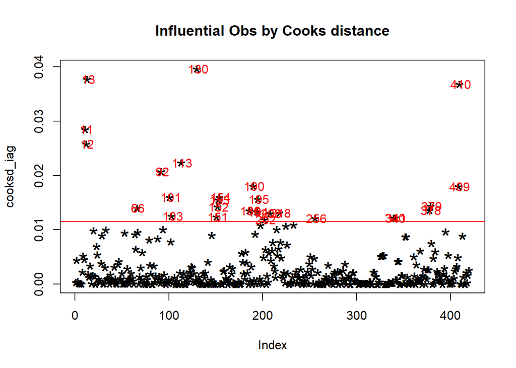

```r
# Outliers: Cook's distance and influential points

par(mfrow = c(1, 1))

cooksd_iag <- cooks.distance(mod_iag_sqrt) # Cook's distance

plot(cooksd_iag, pch = "*", cex = 2, main = "Influential Obs by Cooks distance") # Plot cook's distance
abline(h = 4*mean(cooksd_iag, na.rm = T), col = "red")  # add cutoff line

text(x = 1:length(cooksd_iag) + 1, y = cooksd_iag, labels = ifelse(cooksd_iag> 4*mean(cooksd_iag, na.rm = T),
                                                           names(cooksd_iag),""), col = "red")  # Add labels
```

```r
influential_iag <- as.numeric(names(cooksd_iag)[(cooksd_iag > 4*mean(cooksd_iag, na.rm = T))])  # Influential row numbers

trial2_clean <- trial2_clean2[-influential_iag, ] # Removing influential points from dataset

mod_iag_sqrt_scr <- lm(sqrt(iag_cov) ~.,
                    data = trial2_clean) # Simple linear model on screened data

summary(mod_iag_sqrt_scr)
```

```
##
## Call:
## lm(formula = sqrt(iag_cov) ~ ., data = trial2_clean)
##
## Residuals:
##     Min      1Q  Median      3Q     Max
## -4.4590 -0.9803  0.0170  0.8840  4.4011
##
## Coefficients:
##                                                  Estimate Std. Error t value
## (Intercept)                                    -8.719e+01  3.724e+01  -2.341
## RegionWest and South Central Semiarid Prairies  9.496e-01  5.000e-01   1.899
## RegionWestern Cordillera                        3.249e-01  2.271e-01   1.431
## Elevation                                      -8.313e-04  5.354e-04  -1.553
## MAP                                            -1.174e-03  1.351e-03  -0.869
## T_min                                          -2.148e-01  7.430e-02  -2.891
## MAT                                             8.295e-02  7.903e-02   1.050
## T_max                                          -1.009e-01  2.001e-01  -0.504
## W_stor                                          6.486e-02  3.696e-02   1.755
## Depth                                           1.288e-03  7.486e-03   0.172
## Silt                                            1.051e+00  3.600e-01   2.920
## Sand                                            1.033e+00  3.552e-01   2.909
## pH                                              1.644e-02  6.116e-01   0.027
## SOM                                            -3.049e+00  1.438e+00  -2.120
## EC                                             -1.684e-01  1.422e-01  -1.184
## BD                                             -4.059e+00  2.299e+00  -1.766
## Clay                                            9.070e-01  3.700e-01   2.451
## CEC                                             1.080e-01  7.205e-02   1.499
## CaCO3                                          -5.928e-03  3.313e-03  -1.790
## W_supp                                         -3.723e-03  2.023e-03  -1.841
## litter                                         -3.297e-02  4.926e-03  -6.692
## bare_rock                                      -5.293e-02  6.385e-03  -8.290
## iaf_cov                                        -2.965e-03  1.491e-02  -0.199
## ipf_cov                                        -1.080e-01  2.055e-02  -5.254
## ipg_cov                                        -6.585e-02  1.662e-02  -3.962
## naf_cov                                         2.087e-02  1.784e-02   1.170
## npf_cov                                        -2.091e-02  7.360e-03  -2.841
## nag_cov                                        -7.528e-02  4.936e-02  -1.525
## npg_cov                                        -6.868e-02  7.195e-03  -9.546
## nps_cov                                        -3.029e-02  6.910e-03  -4.384
```

[output cut: 22 more lines]

```
## bare_rock                                      2.23e-15 ***
## iaf_cov                                         0.84251
## ipf_cov                                        2.54e-07 ***
## ipg_cov                                        8.94e-05 ***
## naf_cov                                         0.24285
## npf_cov                                         0.00475 **
## nag_cov                                         0.12807
## npg_cov                                         < 2e-16 ***
## nps_cov                                        1.53e-05 ***
## ---
## Signif. codes:  0 '***' 0.001 '**' 0.01 '*' 0.05 '.' 0.1 ' ' 1
##
## Residual standard error: 1.554 on 363 degrees of freedom
## Multiple R-squared:  0.5163, Adjusted R-squared:  0.4776
## F-statistic: 13.36 on 29 and 363 DF,  p-value: < 2.2e-16
```

```r
sqrt(mean(mod_iag_sqrt_scr$residuals^2)) # Calculating RMSE
```

```
## [1] 1.493358
```

```r
AIC(mod_iag_sqrt_scr) # AIC
```

```
## [1] 1492.493
```

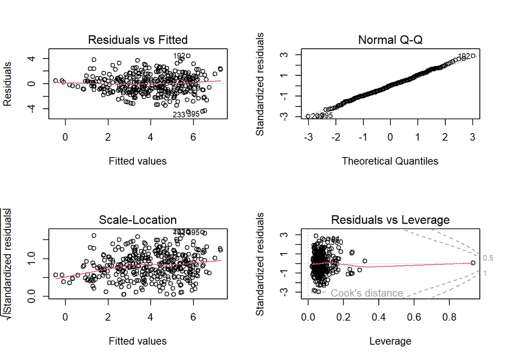

```r
par(mfrow = c(2, 2))

plot(mod_iag_sqrt_scr) # Looks good
```

```r
# Data splitting 70/30

set.seed(1234)

trial2_split <- initial_split(trial2_clean,
                              prop = .7,
                              strata = iag_cov)

trial2_train <- training(trial2_split) # Training dataset
trial2_test <- testing(trial2_split) # Testing dataset

# Recipe - Pre-processing

iag_rec <- recipe(iag_cov ~ ., data = trial2_train) %>%
  step_sqrt(iag_cov) %>% # Square root transformation of iag_cov
  step_dummy(Region) %>% # Code Ecoregion as dummy variable for regression
  step_zv(all_numeric(), -all_outcomes()) %>% # Removing vars with 0 variance
  step_normalize(all_numeric(), -all_outcomes()) # Normalizing numeric variables

# Preparation

iag_prep <- iag_rec %>%
  prep(strings_as_factors = F)

# Model specification - LASSO

lasso_spec <- linear_reg(penalty = 0.1, mixture = 1) %>% # LASSO regression. Penalty and mixture are arbitrary
  set_engine("glmnet")

# Workflow

iag_wf <- workflow() %>%
  add_recipe(iag_rec)

# Fitting LASSO

lasso_fit <- iag_wf %>%
  add_model(lasso_spec) %>%
  fit(data = trial2_train)

lasso_fit %>% # Regression coefficients
  extract_fit_parsnip() %>%
  tidy()
```

```
## # A tibble: 30 × 3
##    term        estimate penalty
##    <chr>          <dbl>   <dbl>
##  1 (Intercept)    3.95      0.1
##  2 Elevation      0         0.1
##  3 MAP            0         0.1
##  4 T_min         -0.324     0.1
##  5 MAT            0.531     0.1
##  6 T_max          0         0.1
##  7 W_stor         0         0.1
##  8 Depth          0         0.1
##  9 Silt           0         0.1
## 10 Sand           0         0.1
## # … with 20 more rows
```

```r
# Tuning parameters

set.seed(1234)

iag_boot <- bootstraps(trial2_train, strata = iag_cov) # bootstrap resampling

tune_spec <- linear_reg(mode = "regression",
                        penalty = tune(),
                        mixture = 1) %>%
  set_engine("glmnet")

lambda_grid <- grid_regular(penalty(), levels = 50)

# Grid tuning

doParallel::registerDoParallel()

set.seed(2020)

lasso_grid <- tune_grid(
  iag_wf %>% add_model(tune_spec),
  resamples = iag_boot,
  grid = lambda_grid
)

lasso_grid %>% # metrics list
  collect_metrics()
```

```
## # A tibble: 100 × 7
##     penalty .metric .estimator  mean     n std_err .config
##       <dbl> <chr>   <chr>      <dbl> <int>   <dbl> <chr>
##  1 1   e-10 rmse    standard   1.79     25  0.0297 Preprocessor1_Model01
##  2 1   e-10 rsq     standard   0.344    25  0.0178 Preprocessor1_Model01
##  3 1.60e-10 rmse    standard   1.79     25  0.0297 Preprocessor1_Model02
##  4 1.60e-10 rsq     standard   0.344    25  0.0178 Preprocessor1_Model02
##  5 2.56e-10 rmse    standard   1.79     25  0.0297 Preprocessor1_Model03
##  6 2.56e-10 rsq     standard   0.344    25  0.0178 Preprocessor1_Model03
##  7 4.09e-10 rmse    standard   1.79     25  0.0297 Preprocessor1_Model04
##  8 4.09e-10 rsq     standard   0.344    25  0.0178 Preprocessor1_Model04
##  9 6.55e-10 rmse    standard   1.79     25  0.0297 Preprocessor1_Model05
## 10 6.55e-10 rsq     standard   0.344    25  0.0178 Preprocessor1_Model05
## # … with 90 more rows
```

```r
p1 <- lasso_grid %>% # Plot with metrics
  collect_metrics() %>%
  ggplot(aes(penalty, mean, color = .metric)) +
  geom_errorbar(aes(
    ymin = mean - std_err,
    ymax = mean + std_err
  ),
  alpha = 0.5
  ) +
  geom_line(linewidth = 1.5) +
  facet_wrap(~.metric, scales = "free", nrow = 2) +
#  scale_x_log10() +
  theme_classic()

lowest_rmse <- lasso_grid %>%
  select_best("rmse")

lowest_rmse # penalty value with lowest RMSE
```

```
## # A tibble: 1 × 2
##   penalty .config
##     <dbl> <chr>
## 1  0.0373 Preprocessor1_Model43
```

```r
best_rsq <- lasso_grid %>%
  select_best("rsq")

best_rsq # penalty value with highest R2
```

```
## # A tibble: 1 × 2
##   penalty .config
##     <dbl> <chr>
## 1  0.0373 Preprocessor1_Model43
```

```r
lasso_grid %>%
  show_best("rmse")
```

```
## # A tibble: 5 × 7
##   penalty .metric .estimator  mean     n std_err .config
##     <dbl> <chr>   <chr>      <dbl> <int>   <dbl> <chr>
## 1  0.0373 rmse    standard    1.75    25  0.0235 Preprocessor1_Model43
## 2  0.0596 rmse    standard    1.75    25  0.0223 Preprocessor1_Model44
## 3  0.0233 rmse    standard    1.76    25  0.0244 Preprocessor1_Model42
## 4  0.0146 rmse    standard    1.77    25  0.0255 Preprocessor1_Model41
## 5  0.0954 rmse    standard    1.77    25  0.0215 Preprocessor1_Model45
```

```r
lasso_grid %>%
  show_best("rsq")
```

```
## # A tibble: 5 × 7
##   penalty .metric .estimator  mean     n std_err .config
##     <dbl> <chr>   <chr>      <dbl> <int>   <dbl> <chr>
## 1 0.0373  rsq     standard   0.348    25  0.0170 Preprocessor1_Model43
## 2 0.0233  rsq     standard   0.347    25  0.0170 Preprocessor1_Model42
## 3 0.0146  rsq     standard   0.347    25  0.0172 Preprocessor1_Model41
## 4 0.00910 rsq     standard   0.346    25  0.0174 Preprocessor1_Model40
## 5 0.0596  rsq     standard   0.345    25  0.0167 Preprocessor1_Model44
```

```r
final_lasso <- finalize_workflow(
  iag_wf %>% add_model(tune_spec),
  lowest_rmse
)

# variable importance

p2 <- final_lasso %>%
  fit(trial2_train) %>%
  extract_fit_parsnip() %>%
  vi(lambda = lowest_rmse$penalty) %>%
  mutate(
    Importance = abs(Importance),
    Variable = fct_reorder(Variable, Importance)
  ) %>%
  ggplot(aes(x = Importance, y = Variable, fill = Sign)) +
  geom_col() +
  scale_x_continuous(expand = c(0, 0)) +
  labs(y = NULL) +
  theme_classic()

final_model <- last_fit(
  final_lasso,
  trial2_split
) %>%
  collect_metrics()

final_model # RMSE and R2
```

```
## # A tibble: 2 × 4
##   .metric .estimator .estimate .config
##   <chr>   <chr>          <dbl> <chr>
## 1 rmse    standard       1.62  Preprocessor1_Model1
## 2 rsq     standard       0.446 Preprocessor1_Model1
```

```r
glimpse(final_model) # RMSE and R2 using glimpse
```

```
## Rows: 2
## Columns: 4
## $ .metric    <chr> "rmse", "rsq"
## $ .estimator <chr> "standard", "standard"
## $ .estimate  <dbl> 1.6167615, 0.4457009
## $ .config    <chr> "Preprocessor1_Model1", "Preprocessor1_Model1"
```

```r
# Fitting a model with the tuned penalty and extract coefficients

final_spec <- linear_reg(penalty = 0.0373, mixture = 1) %>% # Model with tuned penalty
  set_engine("glmnet")

lasso_fit_final <- iag_wf %>% # training
  add_model(final_spec) %>%
  fit(data = trial2_train)

coeff <- tidy(lasso_fit_final) # coefficients

coeff1 <- coeff %>% # select non zero coefficients
  dplyr::filter(estimate != 0)

coeff1
```

```
## # A tibble: 23 × 3
##    term        estimate penalty
##    <chr>          <dbl>   <dbl>
##  1 (Intercept)  3.95     0.0373
##  2 Elevation   -0.247    0.0373
##  3 MAP         -0.00633  0.0373
##  4 T_min       -0.517    0.0373
##  5 MAT          0.401    0.0373
##  6 W_stor       0.155    0.0373
##  7 SOM         -0.0432   0.0373
##  8 EC          -0.127    0.0373
##  9 BD          -0.139    0.0373
## 10 CEC          0.0130   0.0373
## # … with 13 more rows
```

```r
# Predicted vs observed

lasso_fit_final_wf <- workflow() %>%
  add_model(final_spec) %>%
  add_recipe(iag_rec)

lasso_fit_final <- lasso_fit_final_wf %>%
  last_fit(split = trial2_split)

lasso_fit_final_results <- lasso_fit_final %>%
  collect_predictions()

p3 <- ggscatter(lasso_fit_final_results,
          x = ".pred",
          y = "iag_cov",
          color = "#006EA1",
          add = "reg.line",
          add.params = list(color = "black", fill = "gray44"),
          xlab = "Predicted IAG cover (%)",
          ylab = "Measured IAG cover (%)",
          title = "Predicted vs. Measured IAG cover (%)") +
  scale_x_continuous(limits =c (0, 10)) +
  scale_y_continuous(limits = c(0, 10)) +
  stat_cor(aes(label = paste(after_stat(r.label), after_stat(p.label), sep = "~`,`~")),
           label.x = 1, label.y = 8, p.accuracy = 0.001, r.accuracy = 0.01, size = 4) +
  theme_classic()
```

## Including Plots

RMSE and R2:

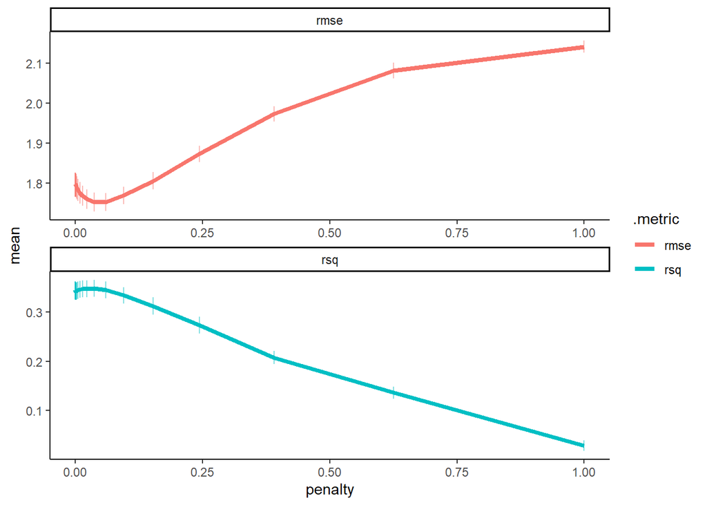

Variable Importance

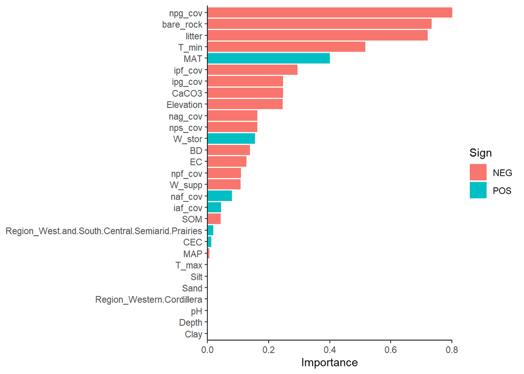

Predicted vs. Measured

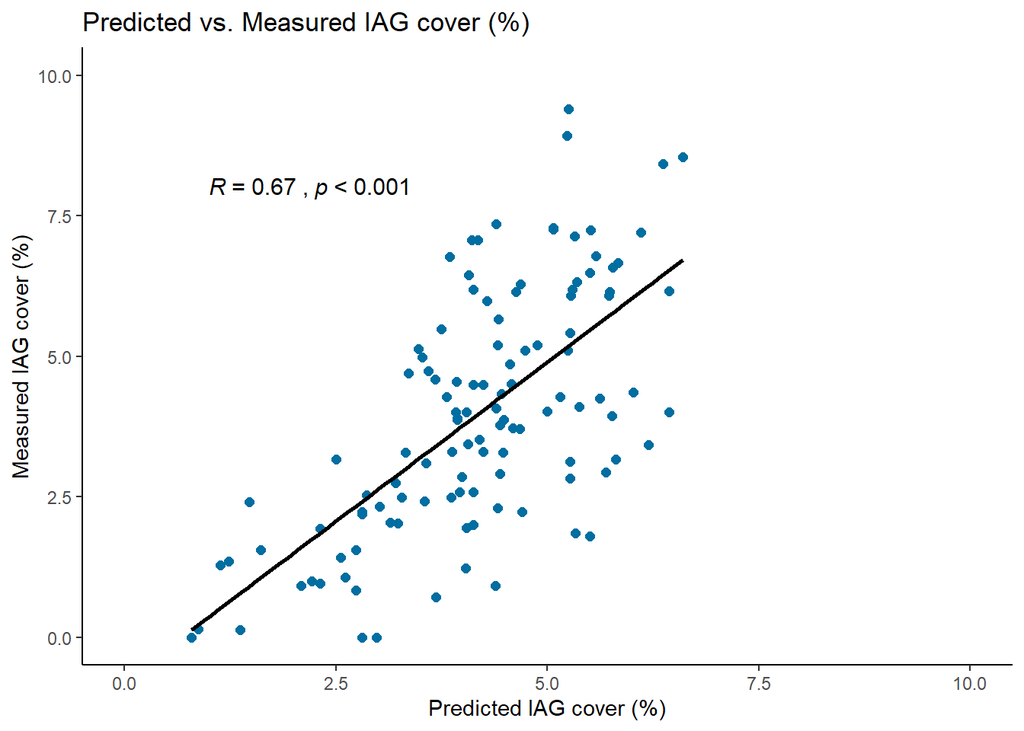